# Trying elastic net regularisation with correlated predictors

Andi Fugard

26 July 2026

```r
library(glmnet)
library(tidyverse)
library(flextable)
library(broom)
```

```r
nice_tab <- function(x) {
  x |> flextable() |> bold(part = "header") |> autofit()
}
```

```r
set.seed(42)
n <- 2000
x_noise <- 0.0
resid_noise <- .5

dat <- tibble(
  l1 = rnorm(n) |> scale(),
  x1 = l1 + rnorm(n, sd = x_noise),
  x2 = l1 + rnorm(n, sd = x_noise),
  x3 = l1 + rnorm(n, sd = x_noise),
  x4 = lm(rnorm(n) ~ x1 + x2 + x3)$resid
) |>
  mutate(across(starts_with("x"), scale)) |>
  mutate(
    y = .2 * (x1 + x2 + x3) + .3 * x4 + rnorm(n, sd = resid_noise)
  ) |>
  select(-l1)
```

First simulate data where $x_1$ to $x_3$ are identical and $x_4$ is uncorrelated with them. Each $x$ is a z-score.

Set $y = 0.2 (x_1 + x_2 + x_3) + 0.3 x_4 + \epsilon$.

Here are the means and SDs:

```r
dat |>
  summarise(across(everything(), list(Mean = mean, SD = sd))) |>
  pivot_longer(
    everything(),
    names_to = c("Variable", ".value"),
    names_sep = "_"
  ) |>
  mutate(across(where(is.numeric), ~ round(.x,2))) |>
  nice_tab()
```

| Variable | Mean | SD |
| --- | --- | --- |
| x1 | 0 | 1.00 |
| x2 | 0 | 1.00 |
| x3 | 0 | 1.00 |
| x4 | 0 | 1.00 |
| y | 0 | 0.84 |

And here are the correlations:

```r
cor(dat) |> round(2) |> as.data.frame() |> rownames_to_column(var = "Variable") |> nice_tab()
```

| Variable | x1 | x2 | x3 | x4 | y |
| --- | --- | --- | --- | --- | --- |
| x1 | 1.00 | 1.00 | 1.00 | 0.00 | 0.71 |
| x2 | 1.00 | 1.00 | 1.00 | 0.00 | 0.71 |
| x3 | 1.00 | 1.00 | 1.00 | 0.00 | 0.71 |
| x4 | 0.00 | 0.00 | 0.00 | 1.00 | 0.34 |
| y | 0.71 | 0.71 | 0.71 | 0.34 | 1.00 |

Since $x_1$ to $x_3$ are identical, we can pick any of them and fit an unpenalised linear regression model (I’ve chosen $x_1$):

```r
options(show.signif.stars = FALSE)
lm_mod <- lm(y ~ x1 + x4, data = dat)
lm_mod |>
  as_flextable() |>
  bold(part = "header")
```

|  | Estimate | Standard Error | t value | Pr(>\|t\|) |
| --- | --- | --- | --- | --- |
| (Intercept) | 0.002 | 0.012 | 0.156 | 0.8760 |
| x1 | 0.603 | 0.012 | 52.446 | 0.0000 |
| x4 | 0.290 | 0.012 | 25.199 | 0.0000 |

The true slope for $x_1 = 3 \cdot 0.2 = 0.6$, when not adjusting for $x_2$ and $x_3$.

```r
mat <- dat |> select(starts_with("x")) |> as.matrix()
```

```r
alphas <- seq(0, 1, .01)
alpha_names <- paste0("alpha_", alphas)
```

```r
fold_n <- 10
fold_ids <- rep(1:fold_n, n / fold_n) |> sample()
stopifnot(length(fold_ids) == n)
```

```r
res   <- alphas |> map(~ cv.glmnet(mat, dat$y, alpha = .x, foldid = fold_ids))
coefs <- res |> map(~ coef(.x, s = "lambda.min") |> as.matrix() |> as.data.frame())
coefs <- map2(
  coefs,
  alpha_names,
  ~ .x %>% rename(!!.y := 1)
)
```

```r
coef_df <- coefs |> bind_cols()
coef_df <- coef_df |>
  rownames_to_column(var = "var") |>
  pivot_longer(
    cols = starts_with("alpha"),
    names_prefix = "alpha_",
    names_to = "alpha",
    values_to = "coef"
  ) |>
  mutate(alpha = as.numeric(alpha))
```

Here’s a plot of the coefficients. Note how the coefficients for the correlated predictors gradually separate as $\alpha$ increases, until only one survives for lasso ($\alpha = 1$):

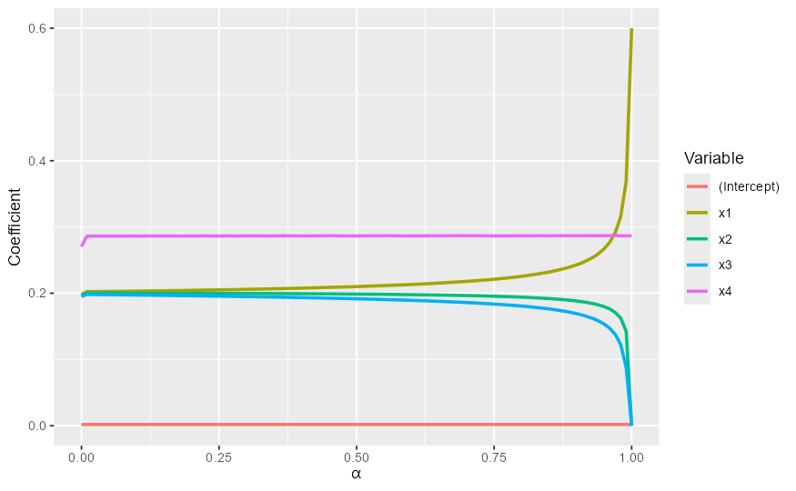

```r
coef_df |>
  ggplot() +
  aes(x = alpha, y = coef, colour = var) +
  geom_line(linewidth = 1) +
  labs(x = expression(alpha),
       y = "Coefficient",
       colour = "Variable")
```

```r
lm_coefs <- coef(lm_mod) |> stack() |>
  rename(var = ind,
         coef = values) |>
  mutate(alpha = "lm")
```

And here are the coefficients for three values of $\alpha$ and the unpenalised regression model with only $x_1$ and $x_4$ as predictors:

```r
coef_df |>
  filter(alpha %in% c(0,.9,1)) |>
  mutate(alpha = paste0("α = ", alpha)) |>
  bind_rows(lm_coefs) |>
  pivot_wider(names_from = alpha, values_from = coef, values_fill = 0) |>
  mutate(across(!starts_with("var"), ~ round(.x, 3))) |>
  rename(Variable = var, "Unpenalised\nregression" = lm) |>
  nice_tab() |>
  colformat_num(
    zero = ""
  )
```

| Variable | α = 0 | α = 0.9 | α = 1 | Unpenalised regression |
| --- | --- | --- | --- | --- |
| (Intercept) | 0.002 | 0.002 | 0.002 | 0.002 |
| x1 | 0.198 | 0.243 | 0.600 | 0.603 |
| x2 | 0.196 | 0.188 |  |  |
| x3 | 0.195 | 0.169 |  |  |
| x4 | 0.271 | 0.287 | 0.287 | 0.290 |